# Report of the 2021 ERIM Open Science Survey

[Dr. Lizette Guzman-Ramirez](https://www.linkedin.com/in/drlizguzman/), [Dr. Antonio Schettino](https://antonio-schettino.com/)

2021-08-20

# Introduction

The RSM & ESE Open Science Survey was open to all researchers from the 6th of April to the 6th of May 2021. Questions were adapted from the [Swinburne Open Science Survey](https://osf.io/vpwf7/).

The survey explored how researchers perceive and use “open science” practices. Eight main topics were covered:

1. Preregistration
2. Open materials/code
3. Open data
4. Pre-publication archiving
5. Open access
6. General experience with open science practices
7. Awareness of available tools
8. Role of ERIM

This report has all the total responses (combined ESE and RSM)[^1].

For any comments or questions, please contact Dr. Lizette Guzman-Ramirez (ERIM Research Data Steward) or Dr. Antonio Schettino (ERS Open Science Coordinator).

```r
ERIM_OS_clean <-
  read_csv(
    here('data', 'preproc', 'CLEAN_20210608_ERIM_OS_Survey.csv')
    ) %>%
  # convert all columns to factors
  mutate(
    across(
      .cols = everything(),
      .fns = ~ as_factor(.)
    )
  )
```

# Respondents

```r
# percentage of (in)complete questionnaires
ERIM_OS_clean_unfinished <-
  ERIM_OS_clean %>%
  group_by(participant) %>%
  summarize(survey = length(which(Finished == TRUE))/length(Finished)) %>%
  count(survey) %>%
  mutate(
    survey = ifelse(survey == 0, "incomplete", "complete"),
    perc = round(n / sum(n) * 100, 2), # calculate percentage
    lab_perc = paste(round(n / sum(n) * 100, 2), "%", sep = "") # percentage as text (for plot labels)
  )
```

```r
ERIM_OS_clean_unfinished %>%
  dplyr::select(-perc) %>%
  rename(percentage = lab_perc) %>%
  kable_custom()
```

| survey | n | percentage |
| --- | --- | --- |
| incomplete | 17 | 13.08% |
| complete | 113 | 86.92% |

We asked participants their school, department, and research institute affiliation together with their position. Almost 60% of the respondents were from RSM, while slightly more than 40% were affiliated to ESE.

```r
#ERIM_OS_clean %>%
#  dplyr::select(-perc) %>%
#  mutate(perc = round(number_responses / sum(number_responses) * 100, 2), # calculate percentage
#    lab_perc = paste(perc, "%", sep = "") # percentage as text (for labels))
#  rename(percentage = lab_perc) %>%
#  kable_custom()
```

```r
#cluster0 <-
#  read_csv(
#    here("data", "preproc", "cluster0.csv")
  #  show_col_types = FALSE
#  ) %>%
  # convert all columns to factors
#  mutate(
#    across(
#      .cols = everything(),
#      .fns = ~ as_factor(.)
#    )
#  )
```

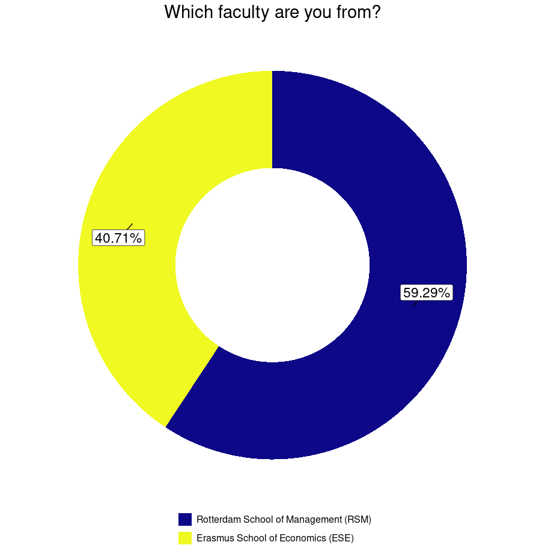

```r
#cluster0 %>%
#  dplyr::select(-c(number_responses, perc)) %>%
#  rename(percentage = lab_perc) %>%
#  kable_custom()

# cluster0 %>%
#   dplyr::select(question, item, lab_perc) %>%
#   rename(percentage = lab_perc) %>%
#   kable_custom()

# Add images from 01_cluster0_figure.R
```

When dividing it into departments inside RSM, the department with higher response was the department of technology & operation management with almost 24% of the respondents, followed by the marketing management department with almost 20% respondents. The business-society management, strategic management & entrepeneurship, and then organization & personnel management departments got the exact same number of respondents (almost 15%) and lastly the departments of finance and accounting and control cover only 6% of the respondents.

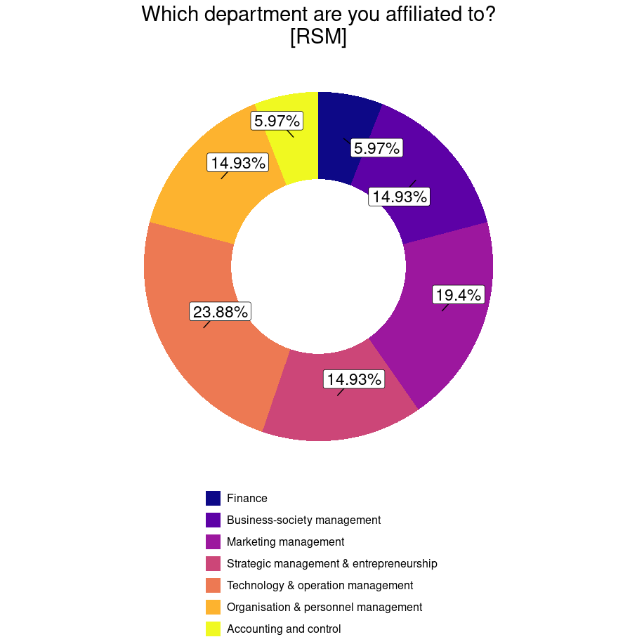

As for ESE, the departmental distribution is almost exactly the same, except for the applied economics department, that covers a bit more than 28%, all the other 3 departments, economics, econometrics, and business economics respondents cover the exact same ratio, almost 24% each.

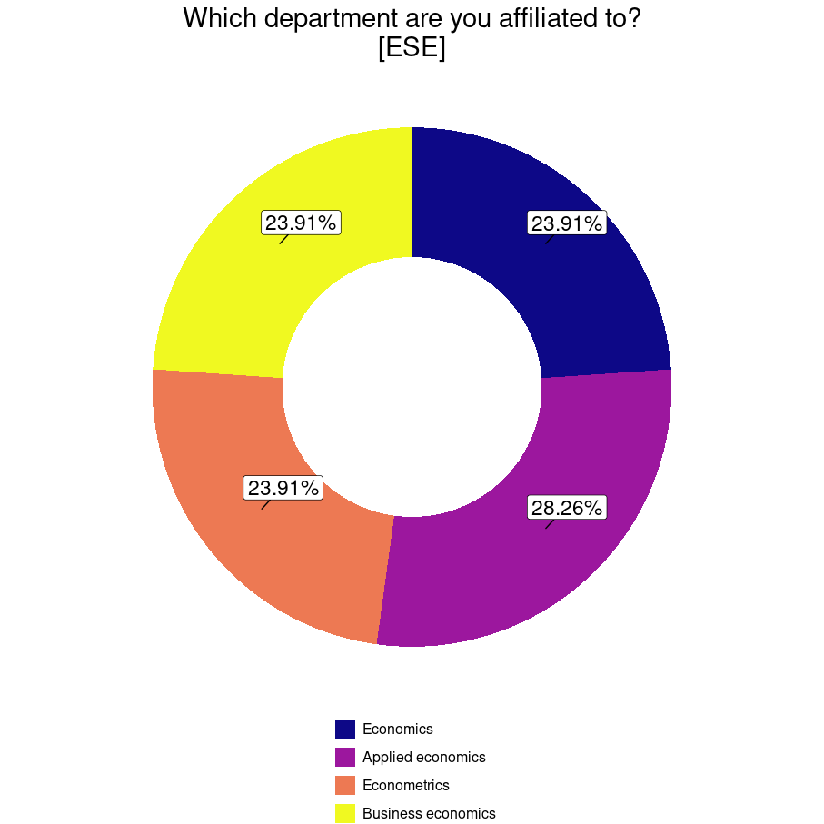

When further dividing into position, the majority of the respondents (a bit more than 52%) were tenured faculty members, followed by a bit more than 22% of the respondents in the PhD position.

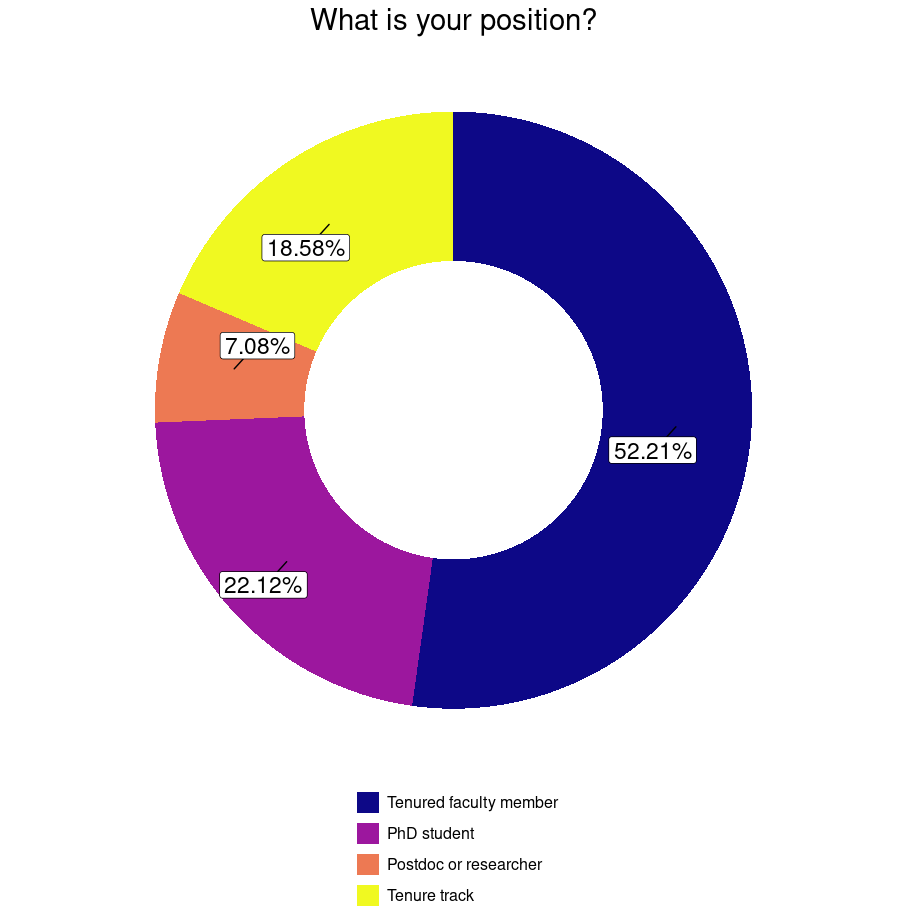

The majority of respondents were affiliated to ERIM (almost 66%), while almost 18% is affiliated to Tinbergen only. A bit more than 7% is affiliated to both ERIM and Tinbergen, and there is almost 10% of researchers that are not affiliated to any research institute.

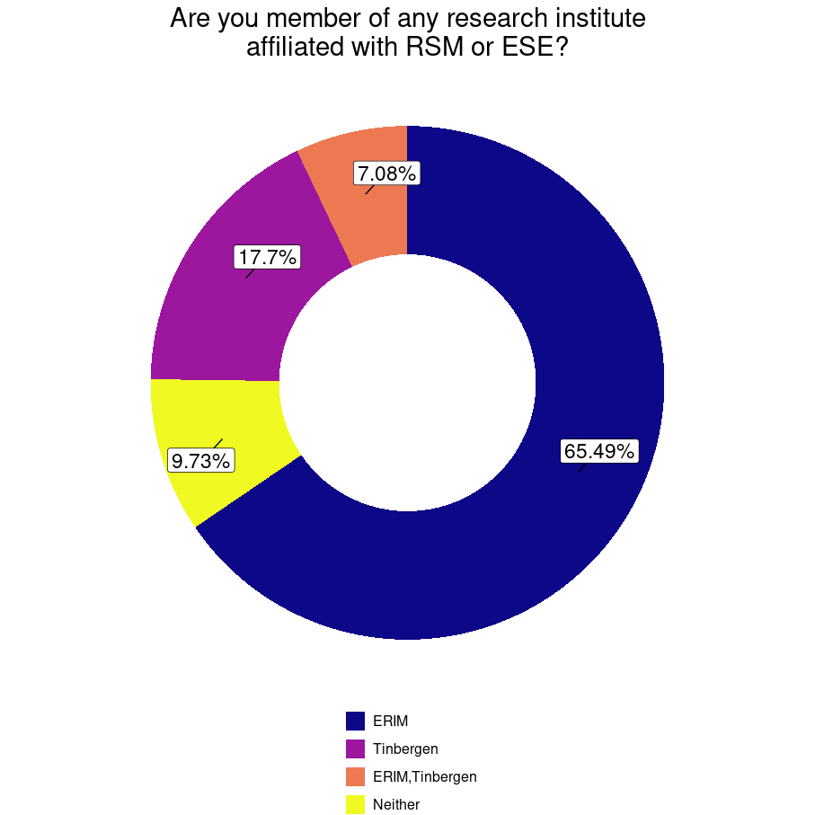

The total survey response rate was 22%, but depending on the research position, the response rate varied up to 34%. The table below presents the total response rate per research position as well as per school.

| Position | RSM | ESE | Total |
| --- | --- | --- | --- |
| PhD student | 20% | 16% | 18% |
| Postdoc or researcher | 23% | 17% | 20% |
| Tenured Track | 27% | 6% | 16% |
| Tenured Faculty Member | 27% | 34% | 30% |
| Total | 25% | 19% | 22% |

# Preregistration

From the question “In your opinion, how important for your field is it that researchers preregister their studies?” we can see that more than 50% of the respondents think preregistration is important (combining very and moderately important), but a bit more than 16% think that preregistration is not at all important.

```r
# # summary of responses to cluster 2
# cluster2 <-
#   ERIM_OS_clean %>%
#   dplyr::filter(
#     Finished == "TRUE" & # keep only complete questionnaires
#       cluster == "2" # keep only questions of relevant cluster
#   ) %>%
#   droplevels() %>% # drop unused levels
#   dplyr::select(-c(Finished, cluster)) %>% # drop unused columns
#   dplyr::select_if(~ sum(!is.na(.)) > 0) %>% # keep columns without NAs
#   # drop_na() %>% # drop rows with missing values
#   rename("item" = "value_1") %>%
#   group_by(question, item) %>%
#   summarize(number_responses = n()) %>%
#   group_by(question) %>%
#   mutate(
#     perc = round(number_responses / sum(number_responses) * 100, 2), # calculate percentage
#     lab_perc = paste(perc, "%", sep = "") # percentage as text (for labels)
#   ) %>%
#   ungroup()
```

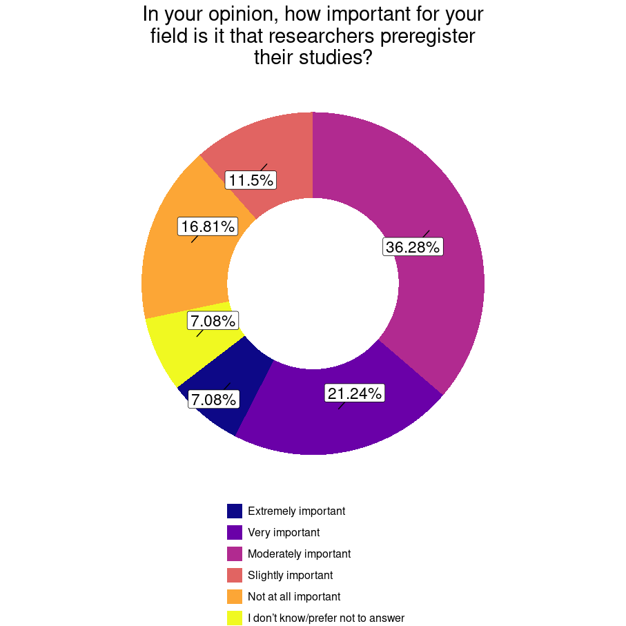

```r
# cluster2 %>%
#   dplyr::select(-c(number_responses, perc)) %>%
#   rename(percentage = lab_perc) %>%
#   kable_custom()

# Add images from 03_cluster2_figure.R
```

From the question “What is your experience with stud preregistration?” we see that both schools are aware of preregistration but mostly have not used it themselves. There is only a bit less than 9% of the respondents that regularly preregister their studies. And a similar percentange (almost 8%) has never heard of preregistration before answering this survey.

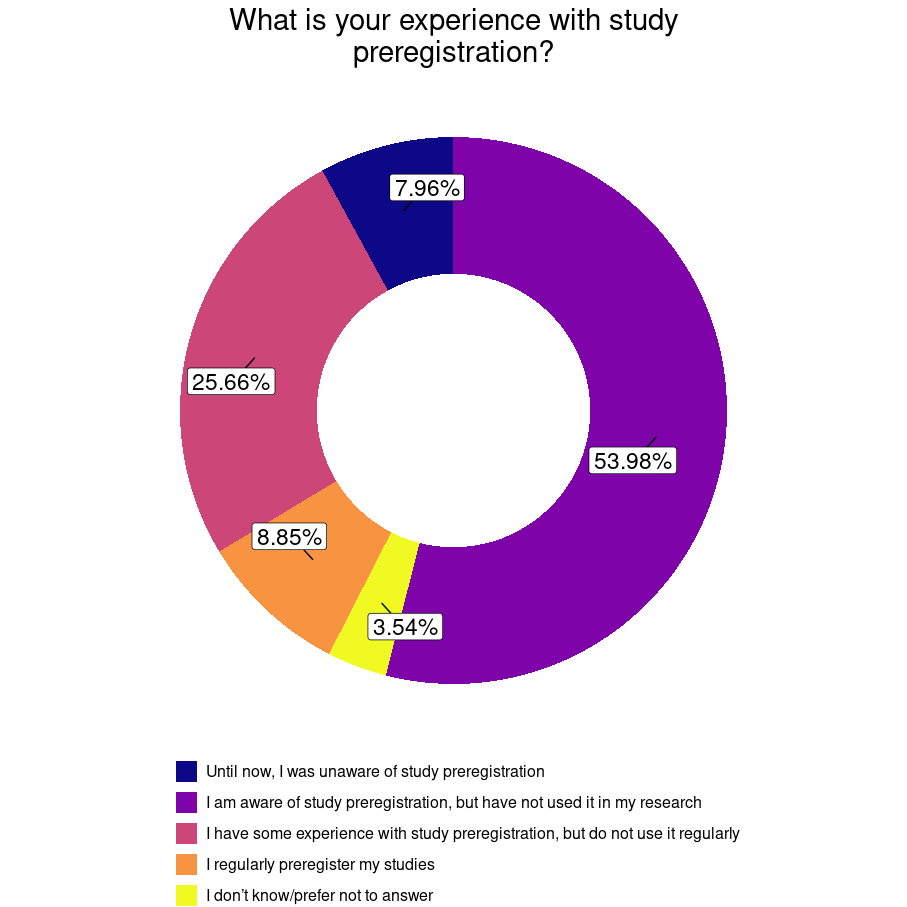

25.66% - I need to look at my data before I can decide how to best analyze it.

19.47% - Preregistration prevents exploratory research.

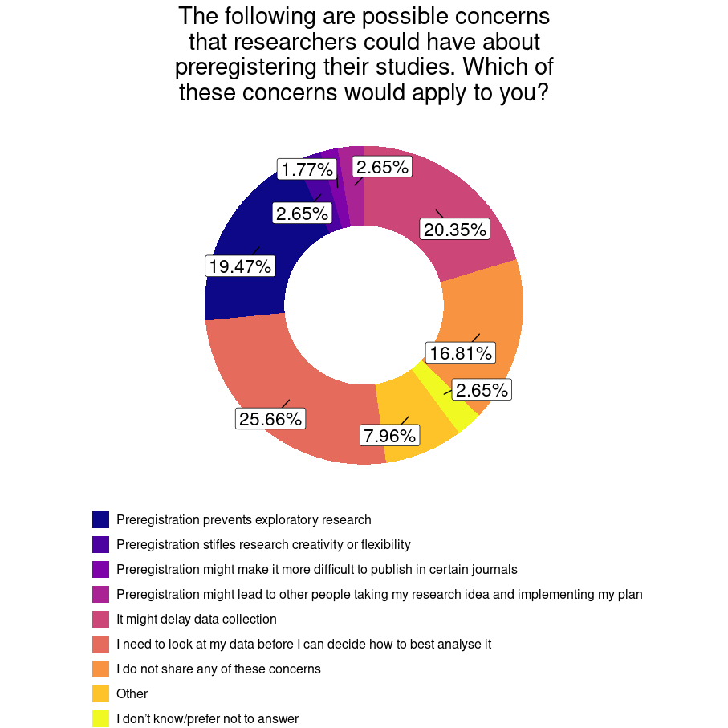

# Open materials/code

```r
#
#  # summary of responses to cluster 3
#  cluster3 <-
#    ERIM_OS_clean %>%
#    dplyr::filter(
#      Finished == "TRUE" & # keep only complete questionnaires
#        cluster == "3" # keep only questions of relevant cluster
#    ) %>%
#    droplevels() %>% # drop unused levels
#    dplyr::select(-c(Finished, cluster)) %>% # drop unused columns
#    dplyr::select_if(~ sum(!is.na(.)) > 0) %>% # keep columns without NAs
#    # drop_na() %>% # drop rows with missing values
#    rename("item" = "value_1") %>%
#    group_by(question, item) %>%
#    summarize(number_responses = n()) %>%
#    group_by(question) %>%
#    mutate(
#      perc = round(number_responses / sum(number_responses) * 100, 2), # calculate percentage
#      lab_perc = paste(perc, "%", sep = "") # percentage as text (for labels)
#    ) %>%
#    ungroup()
```

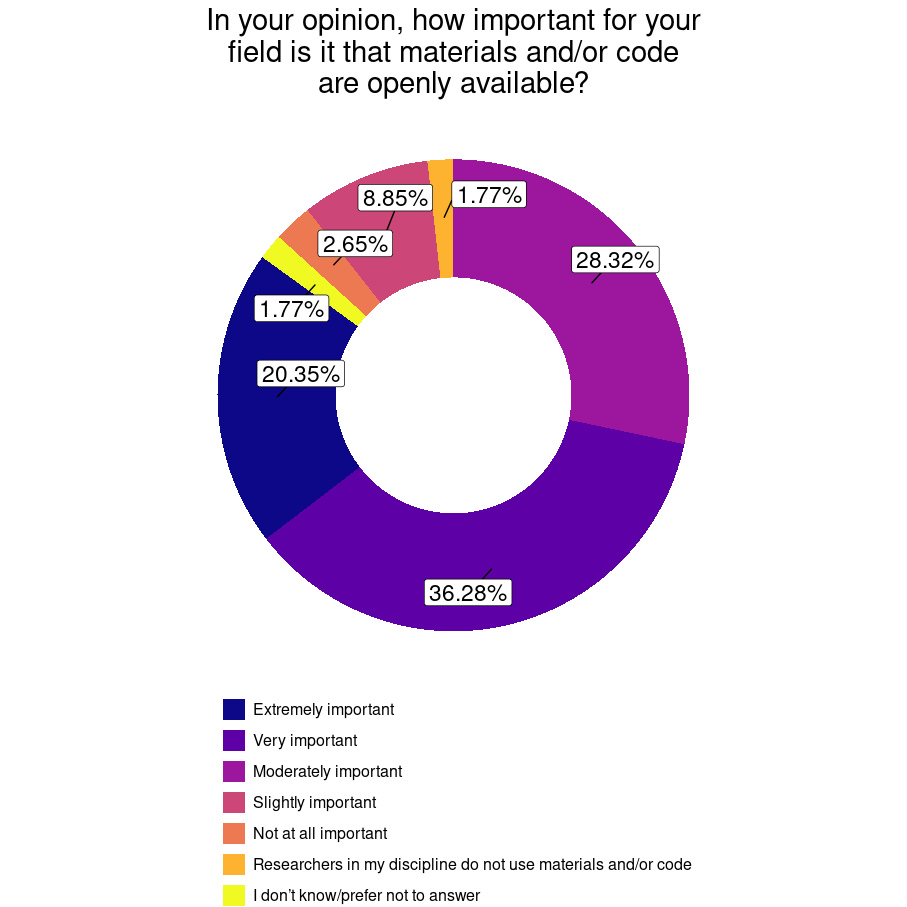

```r
#
#  cluster3 %>%
#    dplyr::select(-c(number_responses, perc)) %>%
#    rename(percentage = lab_perc) %>%
#    kable_custom()

# Add images from 04_cluster3_figure.R
```

From the question “What is your experience with using open materials and/or code?” we see that both schools are aware and have some experience with using open materials and/or code. There is a considerable amount (21%) of researchers that regularly use and/or create open materials and/or code and it is only a bit more than 7% of the respondents that have not heard of open materials and/or code before answering this survey.

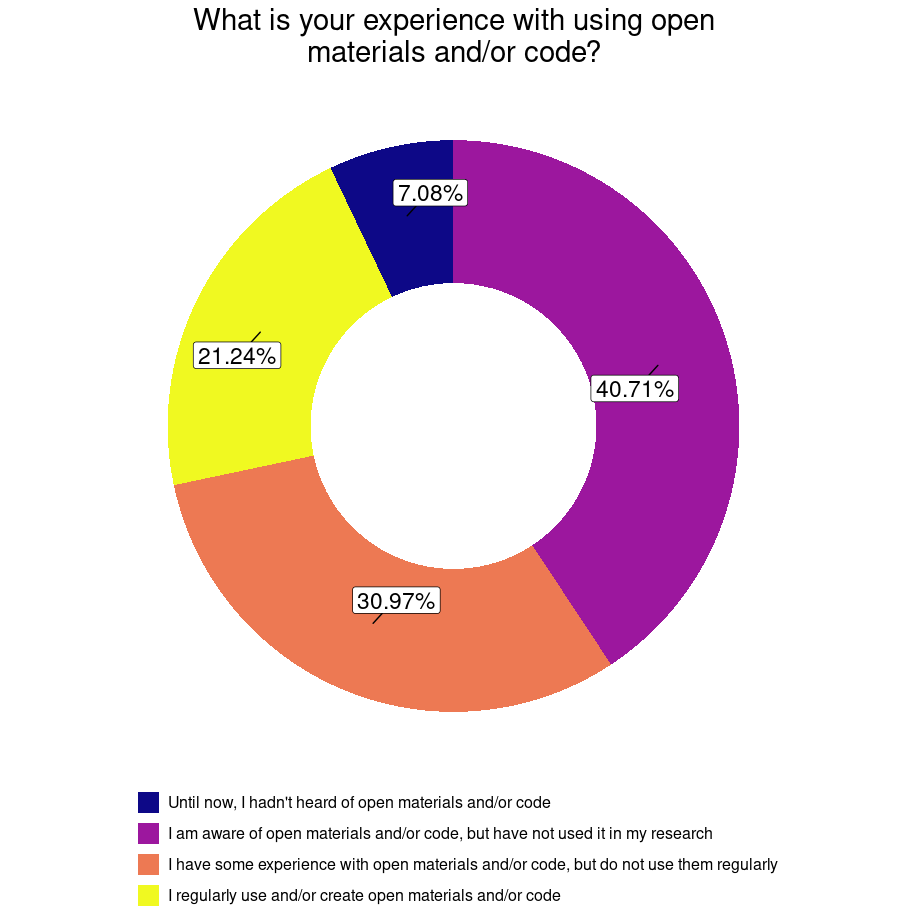

From the question “What is your experience with sharing open materials and/or code?” we can see that a bit more than 30% of respondents are aware of sharing materials and/or code, about 30% have some experience sharing materials and/or code, and similarly almost 30% of respondents regularly share open materials and/or code. Comparing this figure to the one above, we can assume that researchers at ESE and RSM share their materials and/or code more than what they re-use.

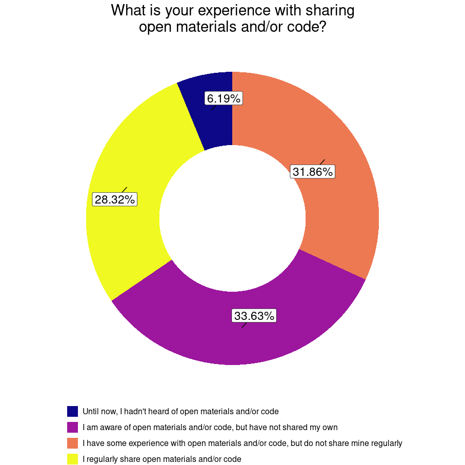

From the question “The following are possible concerns that researchers could have about making their materials and/or code openly available. Which of these concerns would apply to you?” the top 3 concerns for that researchers could have about making their materials and/or code open are the following:

19.47% - Others might find it difficult to understand my materials and/or code.

15.04% - I might lose control over how my materials and/or code are being used.

8.85% - Other researchers might criticise my materials and/or code

It is important to mention that the most popular answer (27.43%) was that researchers do not share any of these concerns with sharing their materials and/or code openly.

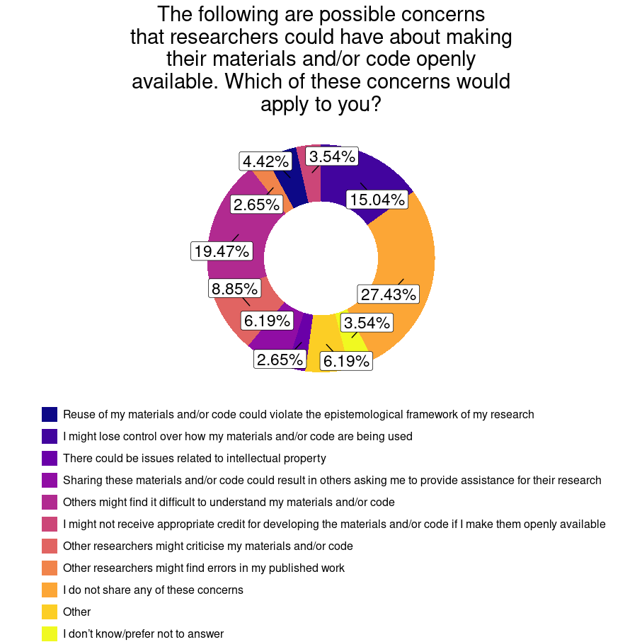

# Open data

From the question “In your opinion, how important for your field is it that data from published research are openly available?” we can see that more than 80% of the respondents think that using open data is important (combining extremely, very, and moderately important), and only a bit more than 5% think is not at all important.

```r
# # summary of responses to cluster 4
# cluster4 <-
#   ERIM_OS_clean %>%
#   dplyr::filter(
#     Finished == "TRUE" & # keep only complete questionnaires
#       cluster == "4" # keep only questions of relevant cluster
#   ) %>%
#   droplevels() %>% # drop unused levels
#   dplyr::select(-c(Finished, cluster)) %>% # drop unused columns
#   dplyr::select_if(~ sum(!is.na(.)) > 0) %>% # keep columns without NAs
#   # drop_na() %>% # drop rows with missing values
#   rename("item" = "value_1") %>%
#   group_by(question, item) %>%
#   summarize(number_responses = n()) %>%
#   group_by(question) %>%
#   mutate(
#     perc = round(number_responses / sum(number_responses) * 100, 2), # calculate percentage
#     lab_perc = paste(perc, "%", sep = "") # percentage as text (for labels)
#   ) %>%
#   ungroup()
```

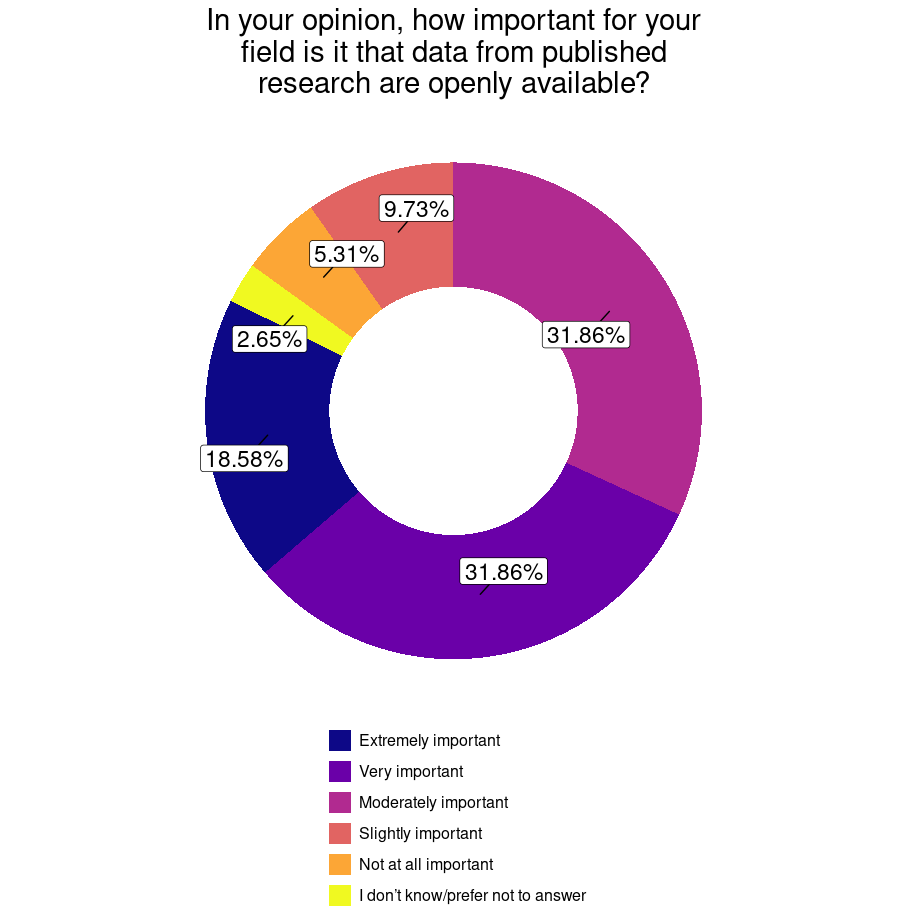

```r
# cluster4 %>%
#   dplyr::select(-c(number_responses, perc)) %>%
#   rename(percentage = lab_perc) %>%
#   kable_custom()

# Add images from 05_cluster4_figure.R
```

From the question “What is your experience with using open data?” we see that both schools are aware and have some experience with using open data. More than 21% of respondents regularly use open data and there is only a very small percentage of respondents (less than 3%) that have never heard of open data before taking this survey.

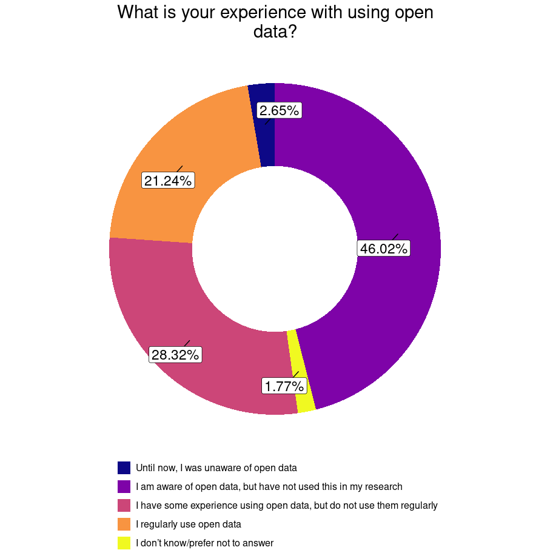

From the question "What is your experience with sharing open data? we can see that almost 77% of respondents are aware of sharing open data and have some experience but do not share their data regularly, and almost 18% of respondents regularly share open data. Comparing this question with the one before, we can see that researchers have more experience using open data, than sharing their data openly.

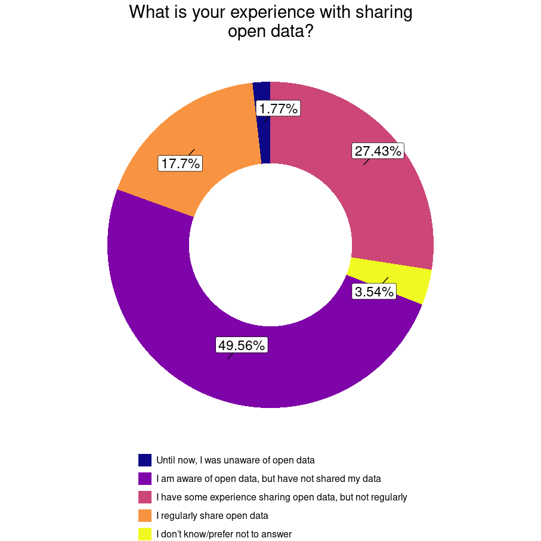

11.5% - There could be issues related to ethics.

But a considerable percentage of respondents (17.7%) do not share any of these concerns.

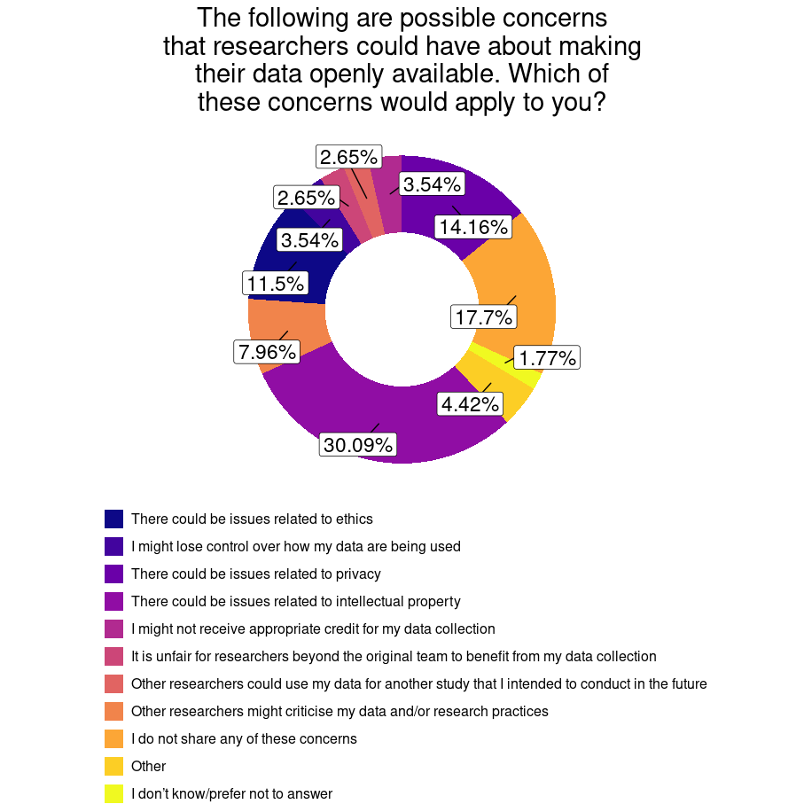

# Pre-publication archiving

From the question “In your opinion, how important is pre-publication archiving for your field?” we can see that around 55% of the respondents think that pre-publication is important (combining extremely, very, and moderately important), but almost 16% thinks it is not at all important.

```r
# # summary of responses to cluster 5
# cluster5 <-
#   ERIM_OS_clean %>%
#   dplyr::filter(
#     Finished == "TRUE" & # keep only complete questionnaires
#       cluster == "5" # keep only questions of relevant cluster
#   ) %>%
#   droplevels() %>% # drop unused levels
#   dplyr::select(-c(Finished, cluster)) %>% # drop unused columns
#   dplyr::select_if(~ sum(!is.na(.)) > 0) %>% # keep columns without NAs
#   # drop_na() %>% # drop rows with missing values
#   rename("item" = "value_1") %>%
#   group_by(question, item) %>%
#   summarize(number_responses = n()) %>%
#   group_by(question) %>%
#   mutate(
#     perc = round(number_responses / sum(number_responses) * 100, 2), # calculate percentage
#     lab_perc = paste(perc, "%", sep = "") # percentage as text (for labels)
#   ) %>%
#   ungroup()
```

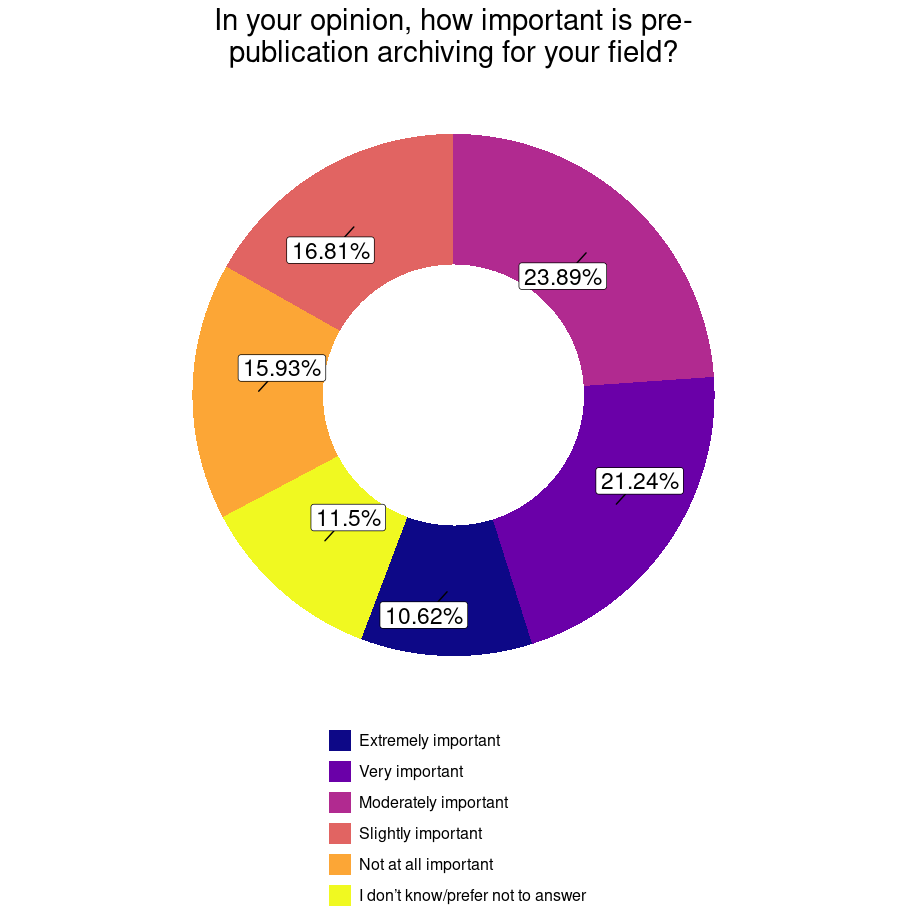

```r
# cluster5 %>%
#   dplyr::select(-c(number_responses, perc)) %>%
#   rename(percentage = lab_perc) %>%
#   kable_custom()

# Add images from 06_cluster5_figure.R
```

From the question “What is your experience with pre-publication archiving?” we see that both schools are aware and have some experience with pre-publications. However, there is a similar percentage of respondents with opposite experience, a bit more than 20% of respondents have extensive experience with preprint archiving, while almost 19% has never heard of pre-publication archiving before they took this survey.

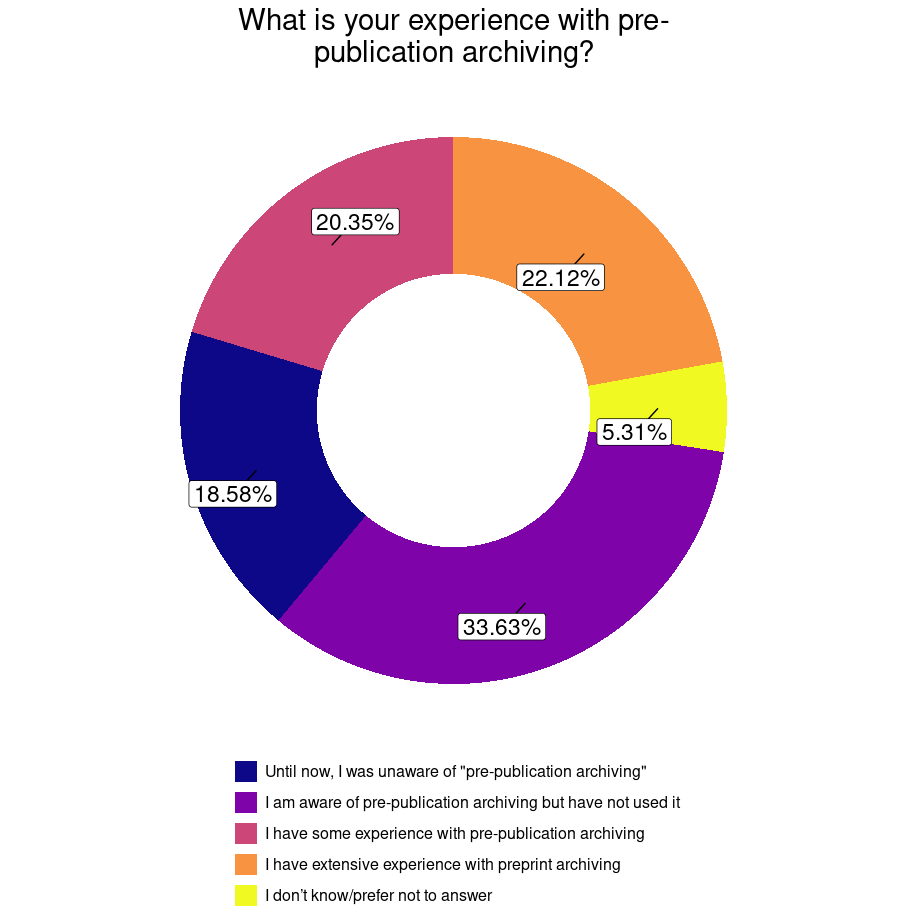

From the question “The following are possible concerns that researchers could have about uploading a manuscript to a pre-publication archive before submitting it for peer review. Which of these concerns would apply to you?” the top 3 concerns that researchers could have about uploading a manuscript to a pre-publication archive before submitting it for peer review are the following:

38.05% - Some journals might not publish findings that are uploaded to a pre-publication archive.

14.16% - Other people might copy my research and publish it before I do.

10.62% - Non-peer-reviewed findings might add noise to the literature.

But the second most common response (26.55%) was that researchers do not share any of these concerns.

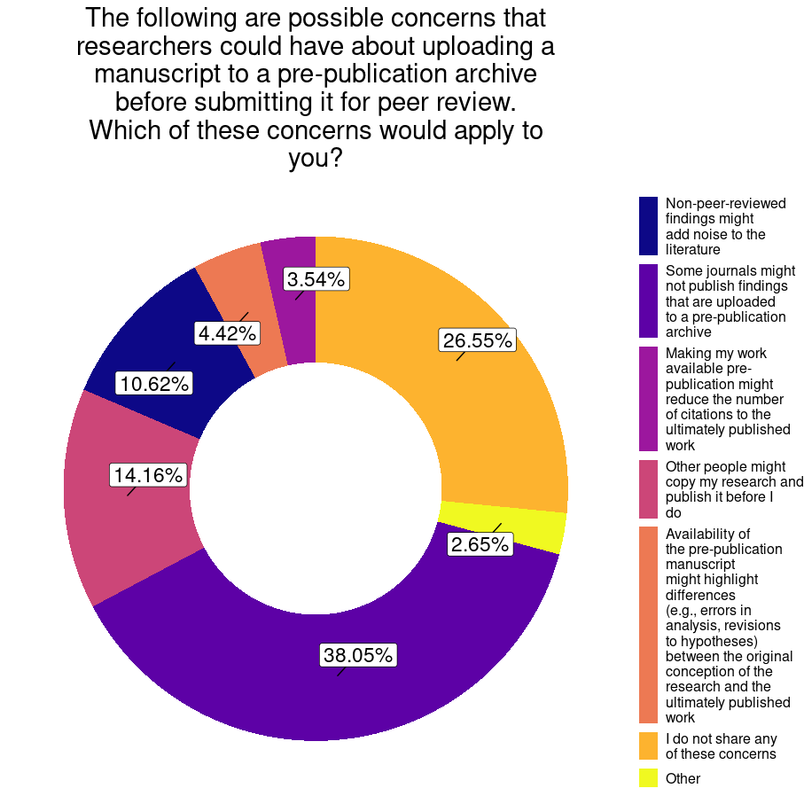

# Open access

From the question Approximately what proportion of your publications from the last 5 years are open access?" we can see that 20% of the respondents don’t know or prefer not to answer. Almost 20% of the respondent have some of their publication open access, while almost 16% have most of their publication open access. However, 17.7% of the respondents have all or none (also 17.7%) of their publication open access.

```r
# # summary of responses to cluster 6
# cluster6 <-
#   ERIM_OS_clean %>%
#   dplyr::filter(
#     Finished == "TRUE" & # keep only complete questionnaires
#       cluster == "6" # keep only questions of relevant cluster
#   ) %>%
#   droplevels() %>% # drop unused levels
#   dplyr::select(-c(Finished, cluster)) %>% # drop unused columns
#   dplyr::select_if(~ sum(!is.na(.)) > 0) %>% # keep columns without NAs
#   # drop_na() %>% # drop rows with missing values
#   rename("item" = "value_1") %>%
#   group_by(question, item) %>%
#   summarize(number_responses = n()) %>%
#   group_by(question) %>%
#   mutate(
#     perc = round(number_responses / sum(number_responses) * 100, 2), # calculate percentage
#     lab_perc = paste(perc, "%", sep = "") # percentage as text (for labels)
#   ) %>%
#   ungroup()
```

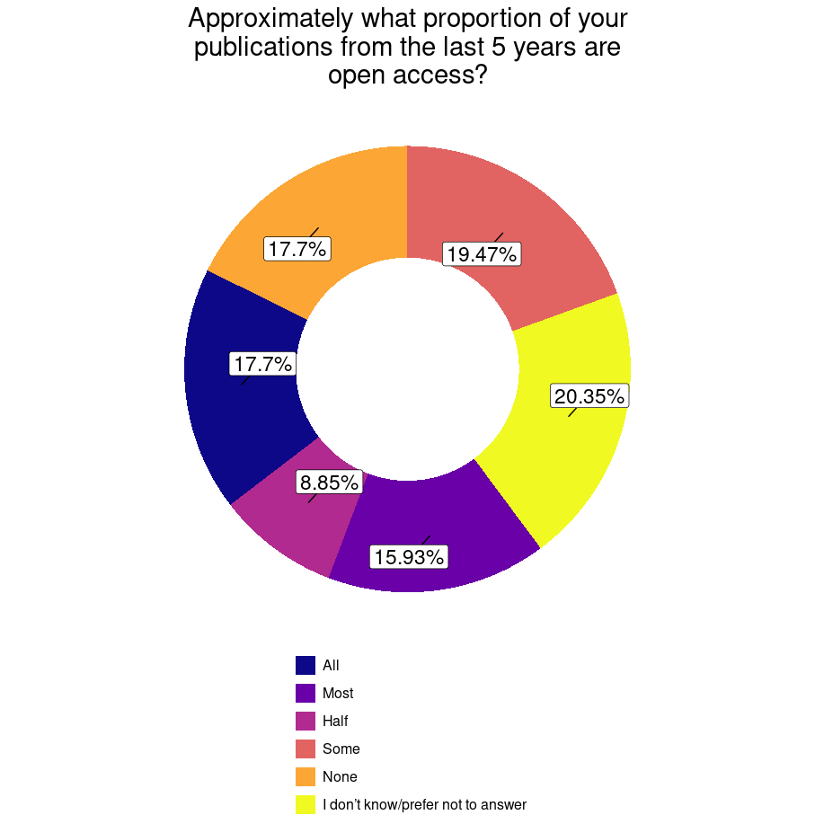

```r
# cluster6 %>%
#   dplyr::select(-c(number_responses, perc)) %>%
#   rename(percentage = lab_perc) %>%
#   kable_custom()

# Add images from 07_cluster6_figure.R
```

From the question Many open access journals charge a fee for processing the article for publication. How have you managed payment of these fees? we see that most Open Access fees were paid using the “blanket agreement” between VSNU and selected academic publisher, otherwise they responded that their open access publications did not involved fees. The 3rd mostly used resource was the Erasmus Open Access Fund.

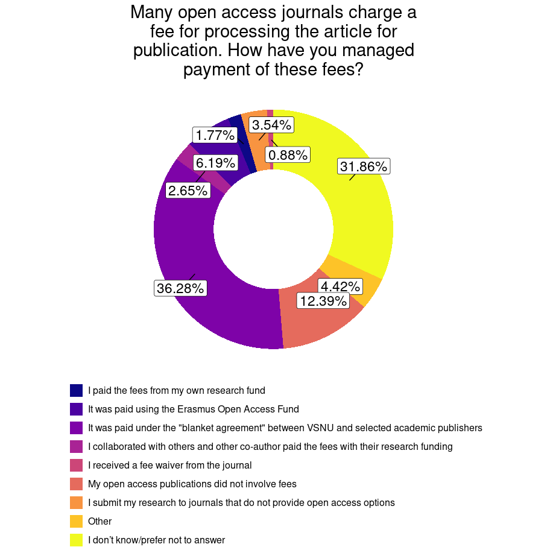

# General experiences with open science practices

From the question “What is your experience with Open Science practices?” more than 50% of the respondents have some experience with Open Science practices, a bit more than 10% have extensive experience, and a bit more than 35% are aware, but have not used any Open Science practices in their research.

```r
# # summary of responses to cluster 1
# cluster1 <-
#   ERIM_OS_clean %>%
#   dplyr::filter(
#     Finished == "TRUE" & # keep only complete questionnaires
#       cluster == "1" # keep only questions of relevant cluster
#   ) %>%
#   droplevels() %>% # drop unused levels
#   dplyr::select(-c(Finished, cluster)) %>% # drop unused columns
#   dplyr::select_if(~ sum(!is.na(.)) > 0) %>% # keep columns without NAs
#   # drop_na() %>% # drop rows with missing values
#   rename("item" = "value_1") %>%
#   group_by(question, item) %>%
#   summarize(number_responses = n()) %>%
#   group_by(question) %>%
#   mutate(
#     perc = round(number_responses / sum(number_responses) * 100, 2), # calculate percentage
#     lab_perc = paste(perc, "%", sep = "") # percentage as text (for labels)
#   ) %>%
#   ungroup()
```

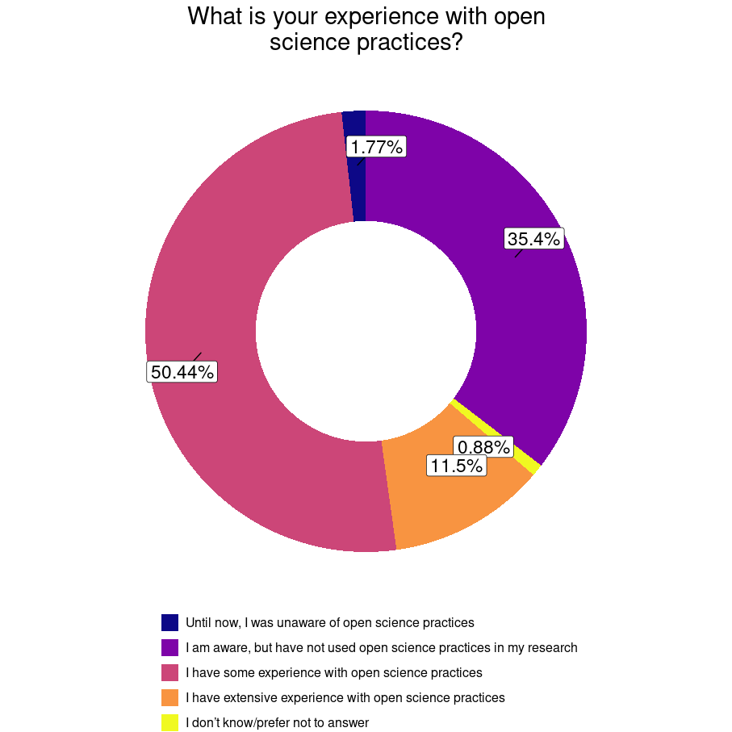

```r
# cluster1 %>%
#   dplyr::select(-c(number_responses, perc)) %>%
#   rename(percentage = lab_perc) %>%
#   kable_custom()

# Add images from 02_cluster1_figure.R
```

From the question “Are you sharing your knowledge about open science practices with others?” we can see that more than 56% of researchers share their knowledge of Open Science informally, while 30% do not.

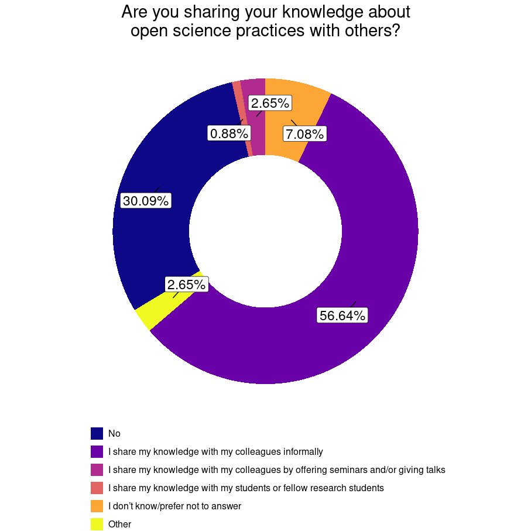

From the question “During March 2021 ERIM launched an ORCID campaign. Did you participate in it and got your own ORCID iD?”, we can see that almost 65% of respondents did not participated since they already had an ORCiD ID, but 23% of the respondents did participate and got an ORCiD ID.

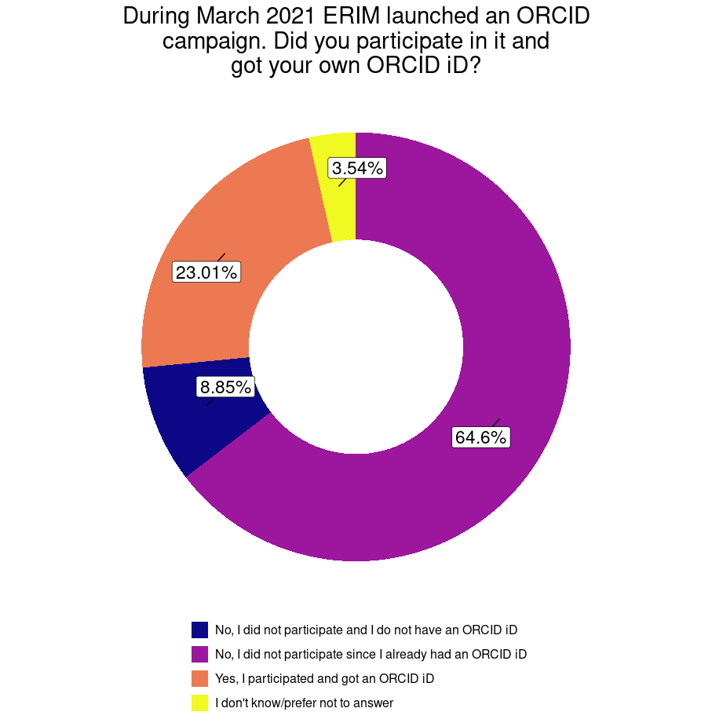

```r
# summary of responses to cluster 7
# cluster7 <-
#   ERIM_OS_clean %>%
#   dplyr::filter(
#     Finished == "TRUE" & # keep only complete questionnaires
#       cluster == "7" # keep only questions of relevant cluster
#   ) %>%
#   droplevels() %>% # drop unused levels
#   dplyr::select(-c(Finished, cluster)) %>% # drop unused columns
#   dplyr::select_if(~ sum(!is.na(.)) > 0) %>% # keep columns without NAs
#   # drop_na() %>% # drop rows with missing values
#   rename("item" = "value_1") %>%
#   group_by(question, item) %>%
#   summarize(number_responses = n()) %>%
#   group_by(question) %>%
#   mutate(
#     perc = round(number_responses / sum(number_responses) * 100, 2), # calculate percentage
#     lab_perc = paste(perc, "%", sep = "") # percentage as text (for labels)
#   ) %>%
#   ungroup()
```

```r
# cluster7 %>%
#   dplyr::select(-c(number_responses, perc)) %>%
#   rename(percentage = lab_perc) %>%
#   kable_custom()

# Add images from 08_cluster7_figure.R
```

13.27% - Lack of recognition in my field about the value of open science practices.

11.5% - Lack of credit in my institution for engaging in open science

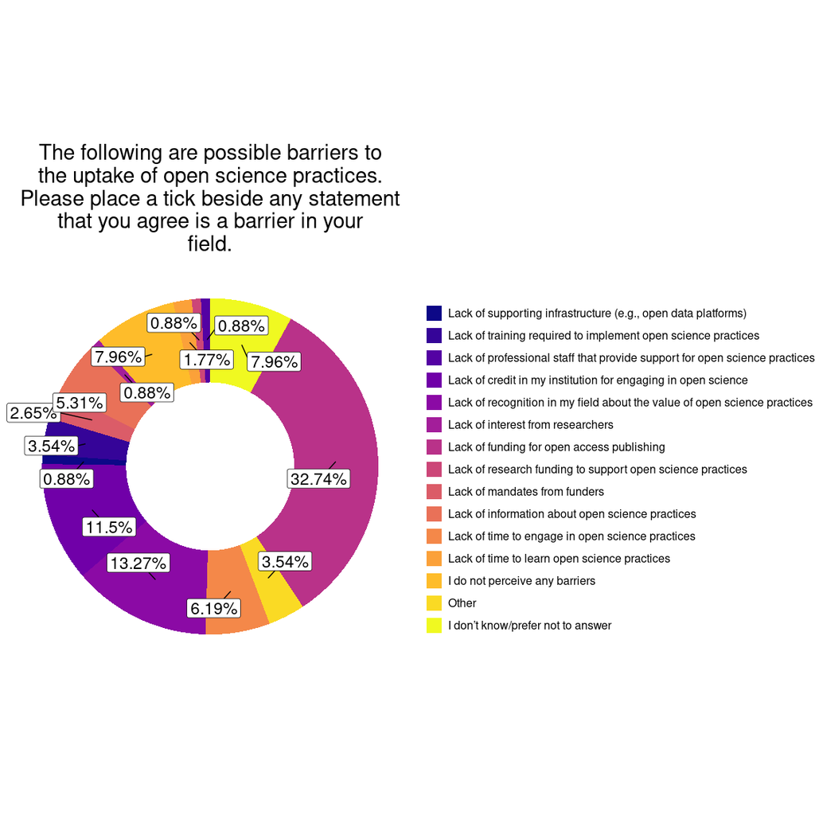

# Awareness of available tools

We asked researchers to indicate their awareness of each of the following open science resources listed below.

Open Science Framework (OSF), a bit more than 83% of the respondents do not use it, it is only a bit less than 17% of researchers that use OSF.

```r
# # summary of responses to cluster 8
# cluster8 <-
#   ERIM_OS_clean %>%
#   dplyr::filter(
#     Finished == "TRUE" & # keep only complete questionnaires
#       cluster == "8" # keep only questions of relevant cluster
#   ) %>%
#   droplevels() %>% # drop unused levels
#   dplyr::select(-c(Finished, cluster)) %>% # drop unused columns
#   dplyr::select_if(~ sum(!is.na(.)) > 0) %>% # keep columns without NAs
#   drop_na() %>% # drop rows with missing values
#   rename("item" = "value_1") %>%
#   group_by(question, item) %>%
#   summarize(number_responses = n()) %>%
#   group_by(question) %>%
#   mutate(
#     perc = round(number_responses / sum(number_responses) * 100, 2), # calculate percentage
#     lab_perc = paste(perc, "%", sep = "") # percentage as text (for labels)
#   ) %>%
#   ungroup()
```

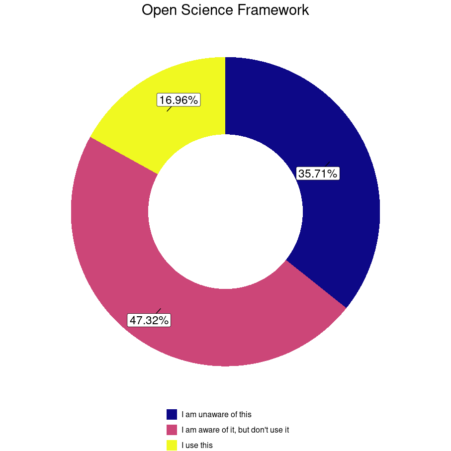

```r
# cluster8 %>%
#   dplyr::select(-c(number_responses, perc)) %>%
#   rename(percentage = lab_perc) %>%
#   kable_custom()

# Add images from 09_cluster8_figure.R
```

GitHub, there are a bit more than 70% of the respondents that do not use it and almost 30% of the respondents use it.

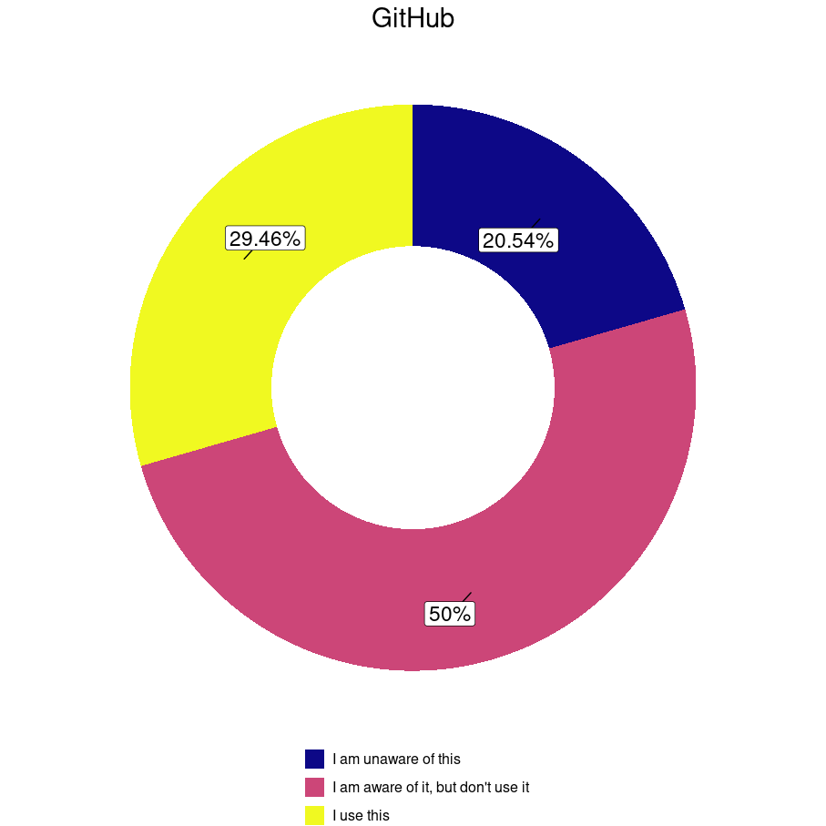

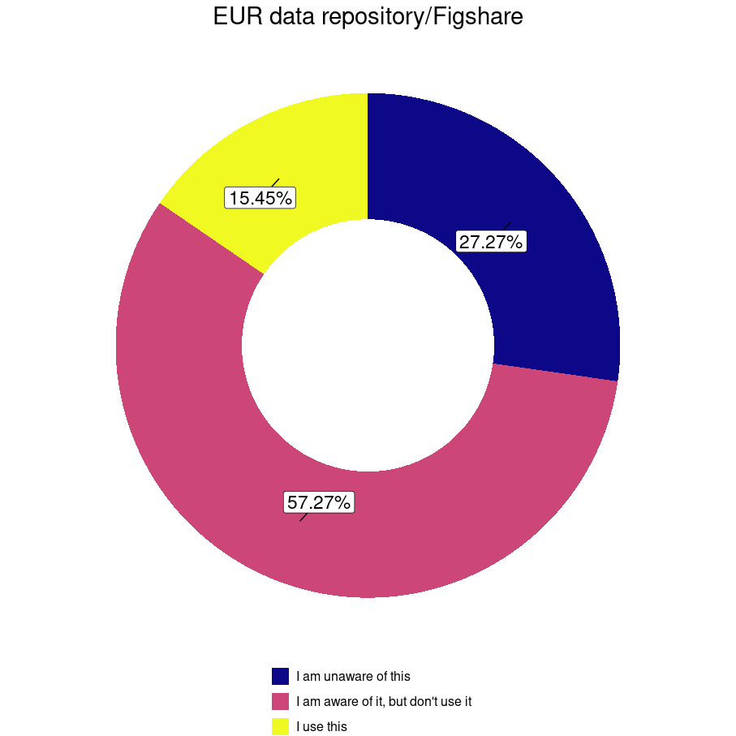

As for the 4TU Center for Reseach Data, all reseachers responded that they do not use it, and only a bit more than 7% have heard of it.

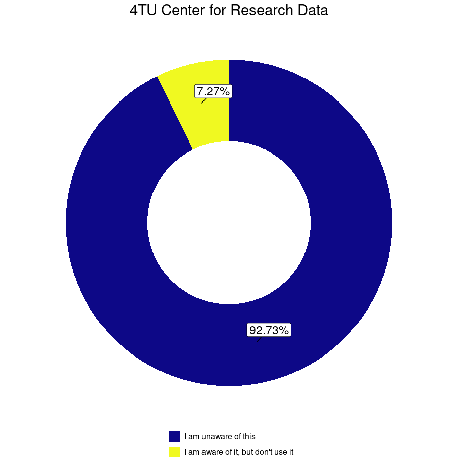